# Introducción a la estadística

author: Alejandro Cáceres date:  
autosize: true

Escuela Técnica Superior de Ingeniería de Barcelona Este  
Universitat Politècnica de Catalunya (UPC)

Capítulo 4

# Objetivo

- Variables aleatorias
- Función de probabilidad
- Media, varianza y momentos de variables aleatorias
- Distribución de probabilidad

# Probabilidad

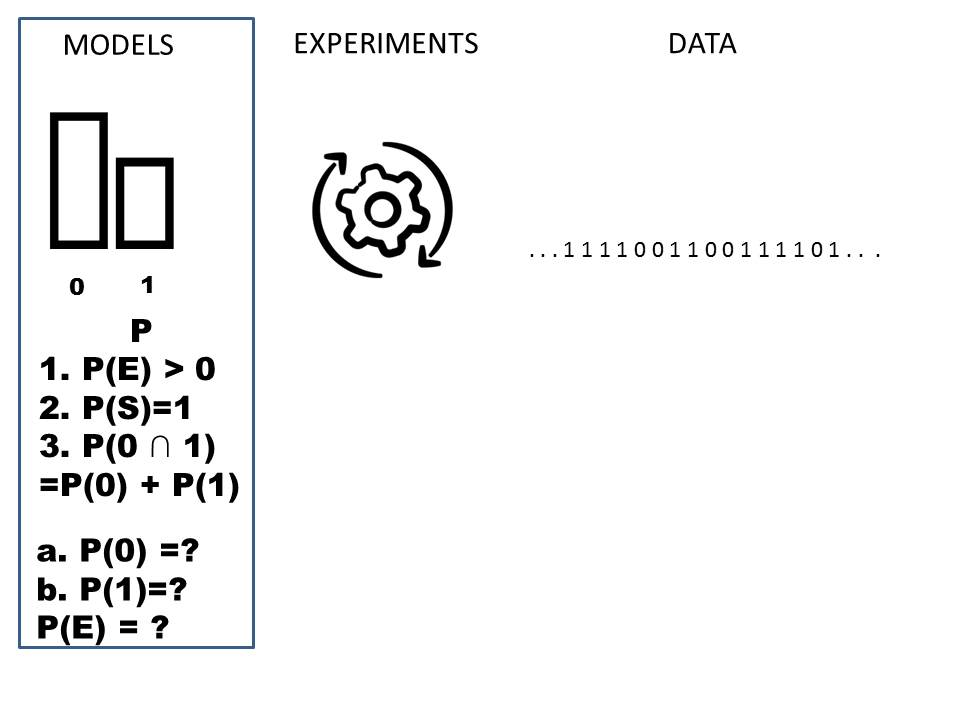

# Probabilidad

¿Cómo asignamos los valores de probabilidad a eventos específicos?

**Interpretación clásica:**

Siempre que un espacio muestral consta de N eventos posibles que son igualmente probables, la probabilidad de cada resultado es $\frac{1}{N}$.

Ten en cuenta que esto es puramente en el espacio modelo. La intención es hacer de la probabilidad una cantidad puramente abstracta (matemática). Nos corresponde a nosotros interpretar lo que significa **igualmente probable**.

# Probabilidad

Considera el lanzamiento de una moneda.

- espacio muestral: {H, T} o {0,1} si asignamos 0: H y 1: T.
- Desde el diseño, antes de lanzar una moneda en particular, no hay **razón** para pensar que un resultado es más probable que el otro.

luego:

- $P(0)=\frac{1}{2}$
- $P(1)=\frac{1}{2}$

Lo mismo es cierto para un dado $P(i)=1/6$ y para la lotería de Navidad $P(i)=\frac{1}{N tickets}$.

# Probabilidad

Si definimos la función $X$ en el espacio muestral de acuerdo con la asignación

$X:\{H,T\} \rightarrow \{0,1\}$

luego

- $P(X=0)=\frac{1}{2}$
- $P(X=1)=\frac{1}{2}$

Llamamos $X$ a **variable aleatoria**

# Probabilidad

¿Cómo podemos obtener probabilidades desiguales?

- Miremos de nuevo los dados e imaginemos que necesitas lanzar un 6 para ganar el juego de parchís.
- tu probabilidad de ganar en el próximo lanzamiento es $P(6)=1/6$
- tu probabilidad de **no** ganar en el próximo lanzamiento es $P(E=1\cup 2\cup 3\cup 4\cup 5)=5/6$

Ten en cuenta que no necesitamos (o no podemos) ejecutar el experimento sólo una vez.

# Probabilidad

Definamos la variable aleatoria

X:{$A$:1 $\cup$ 2 $\cup$ 3 $\cup$ 4 $\cup$ 5, $\bar{A}$:**6**} $\rightarrow$ {0,1}

Luago

- $P(X=0)=\frac{5}{6}$
- $P(X=1)=\frac{1}{6}$

Estas también son las probabilidades del lanzamiento de una moneda desequilibrada.

# Variable aleatoria

**Definición:**

Una variable aleatoria es una función que asigna un número real a cada resultado en el espacio muestral de un experimento aleatorio.

- Más comúnmente, una variable aleatoria es la **medición** numérica de interés que se realiza en un experimento aleatorio.

# Medición

**Definición:**

El proceso de medición es la asignación de un número a una característica de un objeto o evento para que pueda compararse con otros objetos o eventos.

Propiedades:

- tipo: nominal (Hombre / Mujer), ordinal (1º, 2º, .. 3º), intervalo (distancia) y proporciones (longitud)
- magnitud: un valor numérico producido por un instrumento
- unidad: una referencia universal a la que se hacen comparaciones (mediciones)
- **incertidumbre**: errores en el proceso de medición

# Medición

El resultado de un proceso de medición no siempre es el mismo: variable aleatoria

Una variable aleatoria puede ser:

- Discreta (nominal, ordinal)
- Continua (intervalo, relación)

# Variable aleatoria discreta

El valor de una variable aleatoria puede comprender varios eventos primarios (de igual probabilidad)

- $X=0$ (el evento de perder) contiene 5 eventos primarios de 6, por lo tanto: $P(X=0)=\frac{5}{6}$

Muchas veces no conocemos los eventos primarios pero sí el resultado de una medición.

# Variable aleatoria discreta

Ejemplo extremo:

- En física, llamamos a un evento primario, micro-estado, al suceso para el que sabemos todas las posiciones y velocidades de todos los átomos de un gas.
- la temperatura de un gas en equilibrio con el ambiente es una **variable aleatoria** y un valor de 20 grados es un evento del gas que corresponde a muchos micro-estados. La temperatura es la energía cinética promedio que corresponde a muchísimos microestados todos con la misma probabilidad.

Conocemos la temperatura pero no los micro-eventos que pueden dar esa temperatura.

¿cómo asignamos un valor de probabilidad a una temperatura dada?

# Variable aleatoria discreta

¿Cómo podemos partir del conjunto de mediciones y asignar una probabilidad para cada resultado posible de una medición?

Consideremos un ejemplo simple:

- Imaginemos que queremos medir qué tan ruidosa es la transmisión de bits entre dos computadoras.
- Si tuvieramos que transmitir 100 bits en un canal totalmente ruidoso: es igual de probable trasmitir un error que no trasmitirlo.

¿cuál es la probabilidad de transmitir 1, 2, 3, … 100 errores?

# Variable aleatoria discreta

- Espacio muestral de un bit:

$S=\{C:correct, \bar{C}=error\}$

Supongamos que cada uno de estos eventos es igualmente probable

$P(C)=1/2$; $P(\bar{C})=1/2$

- Espacio muestral de 2 bits:

$S=\{(C_1, C_2), (C_1, \bar{C_2}), (\bar{C_1}, C2), (\bar{C_1}, \bar{C_2})\}$, con $dim(S)=n=4$

Supongamos que cada uno de estos eventos es igualmente probable

$P(C_1, C_2)=P(C_1, \bar{C_2})=P(\bar{C_1}, C2)=P(\bar{C_1}, \bar{C_2})=1/n$

Recuerda la matrix de probabilidad conjunta.

# Función de probabilidad

- Definamos la variable aleatoria $K$ para la transmisión de un bit

$K:\{C,\bar{C}\} \rightarrow \{0,1\}$

- Enviemos 2 bits, cada uno las posibles parejas de bits tienen la misma probailidad

$P(0,0)=P(0,1)=P(1,0)=P(1,1)=1/n=1/4$

Ahora contemos los errores en cada posible **resultado** del exerimento con la variable aleatoria $X$

$(0,0)$: **X=0**  
$(0,1)$: **X=1**  
$(1,0)$: **X=1**  
$(1,1)$: **X=2**

¿Cuáles son las probabilidades para $X=0,1,2$?

$P(X=0)=P(0,0)=1/4$

$P(X=1)=P(0,1)+P(1,0)=1/2$

$P(X=2)=P(1,1)=1/4$

# Función de probabilidad

Enviemos 4 bits (4 eventos) con posibles resultados

¿Cuáles son las probabilidades para $X=0,1,2,3,4$?

Para cada bit hay dos resultados posibles, para 4 bits hay $n=2\times 2 \times 2 \times 2=2^{4}$ eventos mutuamuente excluyentes (todos de igual probabilidad).

# Función de probabilidad

Número de eventos primarios que corresponden a un número de errores dado (cada valor de la variable aleatoria $X$)

| 0 | 1 | 2 | 3 | 4 | total |
| --- | --- | --- | --- | --- | --- |
| $n_0$ | $n_1$ | $n_2$ | $n_3$ | $n_4$ | $n_{\cdot}$ |

Esta es como una tabla de frecuencia relativas pero donde contamos el número de posibilidades de obtener un resultado de la variable aleatoria.

Dado que los eventos primarios son igualmente probables, la probabilidad para cada valor de $X$ es su valor en la tabla de arriba dividido por el número total de posibilidades $n_{\cdot}=2^4$

| $X$ | 0 | 1 | 2 | 3 | 4 | total |
| --- | --- | --- | --- | --- | --- | --- |
| $P(X=x)$ | 1/16 | 4/16 | 6/16 | 4/16 | 1/16 | 1 |

(los valores de $X$ corresponden al *Triángulo de Pascal*)

Nota: ¡este no es el resultado de un experimento! es el resultado de nuestras suposiciones.

# Función de probabilidad

Es como seleccionar grupos de tamaño $x$ conjuntos de un conjunto de $n$

- $X=0$ aparece como el número de subconjuntos de tamaño 0 ($n_0=1$) de un conjunto de 4 elementos
- $X=1$ aparece como número de subconjuntos de tamaño 1 ($n_1=4$)
- $X=x$ aparece como número de subconjuntos de tamaño x ($n_x=\binom 4 x$)

$X$ en mayúscula es la variable (resultado posible), $x$ tamaño en miníscula es un valor **observado** de $X$

- $\binom 4 x$ es el coeficinte binomial de $4$ y $x$
- Ten en cuenta que $\sum_{x=0}^4 \binom 4 x= \sum_{x=0,...4} n_x =2^4$ es el tamaño del espacio muestral

# Coeficiente binomial

El coeficiente binomial entre dos números $n$ y $k$ se define como

$\binom n k =\frac{n!}{k!(n-k)!}$

donde el factorial $!$ en un número $r$ se define como $r!=1 * 2 * 3 * ... (r-1) * r$

- el coeficiente binomial dan los coeficientes de expansión

$(x+y)^n=\sum_{i=0}^n\binom n k x^{n-k}y^k$

- dan el número de subconjuntos de tamaño $k$ que se pueden hacer con un conjunto de tamaño $n$ ($k$ número en la fila $n$ del triángulo de Pascal)

# Función de probabilidad

Por lo tanto, la probabilidad de cada valor de la variable aleatoria $X$ es

$P(X=0)=1/16$  
$P(X=1)=4/16$  
$P(X=2)=6/16$  
$P(X=3)=4/16$  
$P(X=4)=1/16$

o

$f(x)=\frac{\binom n x}{n^2}$

La función definida por $f(x_i)=P(X=x_i)$ se llama **función de masa de probabilidad de X**

# Función de probabilidad

**Definición:**

Para una variable aleatoria discreta $X$ con valores posibles $x_1, x_2, .., x_m$, una probabilidad La función de masa es una función tal que

- $f(x_i)\geq 0$
- $\sum_{i=1}^m f(x_i)=1$
- $f(x_i)=P(X=x_i)$

# Función de probabilidad

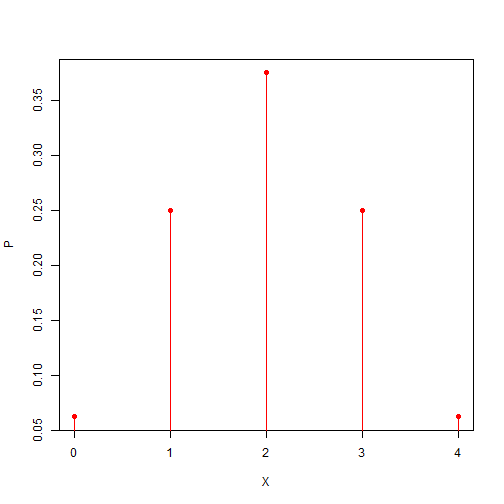

# Función de probabilidad

- Hemos mostrado cómo asignar una función de masa de probabilidad a una variable $X$ que es el resultado de un experimento dado.
- Ten en cuenta que la definición de $X$ y su función de masa de probabilidad es general sin referencia a ningún experimento. Las funciones viven en el espacio modelo.
- $X$ y $f(x)$ son objetos abstractos que pueden o no asignarse a un experimento
- Tenemos la libertad de construirlos como queramos siempre que respetemos su definición.
- Tienen unas propiedades que se derivan exclusivamente de su definición.

# Función de probabilidad

Ejemplo:

Considera la siguiente variable aleatoria $X$ sobre los resultados

| Resultado | a | b | c | d | e | f |
| --- | --- | --- | --- | --- | --- | --- |
| X | 0 | 0 | 1.5 | 1.5 | 2 | 3 |

Si cada resultado es igualmente probable (eventos primarios), ¿cuál es la función de masa de probabilidad de $x$?

# Función de probabilidad

$f(0)=P(X=0)=2/6$  
$f(1.5)=P(X=1.5)=2/6$  
$f(2)=P(X=2)=1/6$  
$f(3)=P(X=3)=1/6$

Podemos calcular, por ejemplo, las siguientes probabilidades para los valores de X

- $P(X>3)$
- $P(X=0\, \cup \, X=2 )$
- $P(X \leq 2)$

# Función de probabilidad

O Considera que no nos importa cuáles son los eventos primarios pero tenemos una definición directa de la función de masa de probabilidad

| X | -2 | -1 | 0 | 1 | 2 |
| --- | --- | --- | --- | --- | --- |
| f(x) | 1/8 | 2/8 | 2/8 | 2/8 | 1/8 |

Todavía podemos calcular las probabilidades sobre los valores de $X$

$P(X\leq 2)$  
$P(-1\leq X \cap X\leq 1)$  
$P(X>2)$  
$P(X\leq -1 \, \cup \,X=2)$

# Media y varianza

Las funciones de masa de probabilidad tienen dos propiedades principales

- su centro
- su dispersióm

Podemos preguntar,

- ¿alrededor de qué valores de $X$ se concentra la probabilidad?
- ¿Cuán dispersos están los valores de $X$ en relación con sus probabilidades?

# Media y varianza

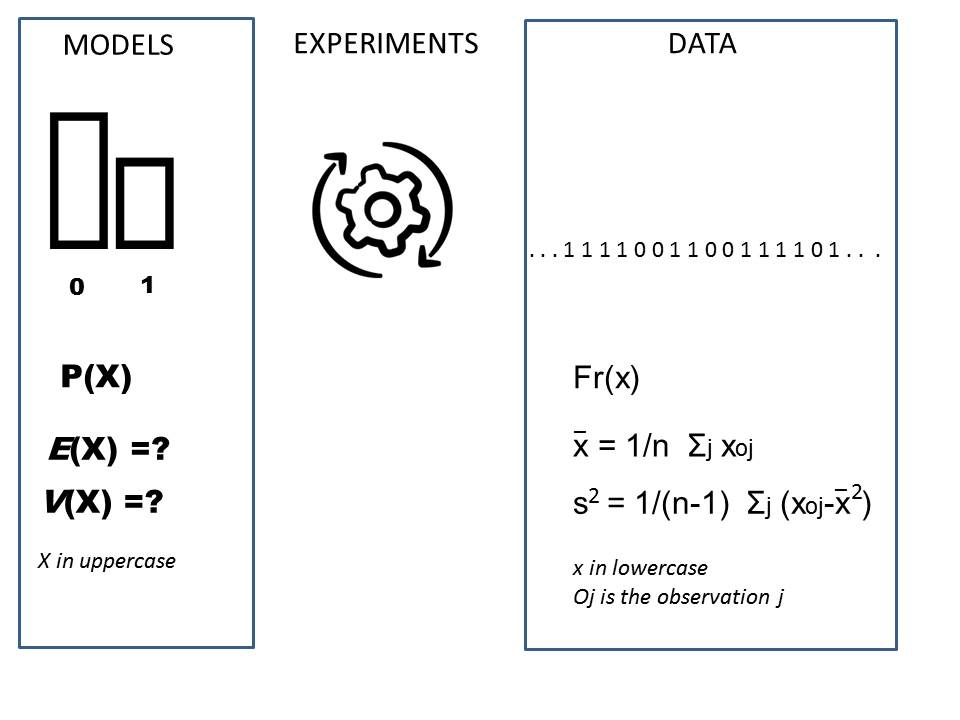

# Media y varianza

Tomemos la perspectiva frecuentista y recordemos que cuando hablamos de datos

- Recordemos que el promedio en términos de las frecuencias de los valores de $x_i$ (resultados)

$$\bar{x}=\sum_{i=1..m} x_i \frac{n_i}{n}$$

es el centro de gravedad de las observaciones, $m$ es el número posible de resultados para $x_i$ y $n$ la cantidad total de observaciones.

¿Cuál sería el centro de gravedad de $P(X=x_i)$ ($n \rightarrow \infty$)?

# Media y varianza

**Definición**

La media, denotada $\mu$, de una variable aleatoria con función de masa de probabilidad $f(x)$ se define como

$$\mu =\sum_{i=1}^m x_i f(x_i)$$

La media también se conoce como **el valor esperado** de la variable aleatoria

$$E(X)=\mu$$

# Media y varianza

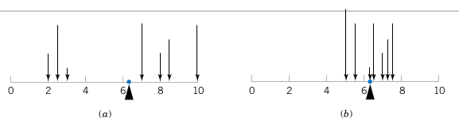

Es el centro de gravedad de las probabilidades: el punto donde se equilibran las cargas de probabilidad en una balanza.

# Media y varianza

¿Cuál es la media de $X$ si su función de masa de probabilidad $f(x)$ está dada por

$P(X=0)=1/16$  
$P(X=1)=4/16$  
$P(X=2)=6/16$  
$P(X=3)=4/16$  
$P(X=4)=1/16$

$$\mu =E(X)=\sum_{i=1}^m x_i f(x_i)$$

$E(X)=$**0** * 1/16 + **1** * 4/16 + **2** * 6/16 + **3** * 4/16 + **4** * 1/16 =2

# Media y varianza

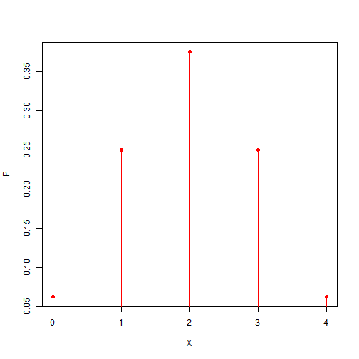

# Media y varianza

En términos similares, definimos la distancia media al cuadrado de la media:

**Definición**

La varianza, escrita como $\sigma^2$ o $V(X)$, de una variable aleatoria discreta $X$ con función de masa $f(x)$ está dada por

$$\sigma^2 =V(X)=\sum_{i=1}^m (x_i-\mu)^2 f(x_i)$$

- $\sigma$ se llama desviación estándar de la distribución
- Piensa en la varianza como el momento de inercia alrededor de la media.

# Media y varianza

¿Cuál es la varianza de $X$ si su función de masa de probabilidad $f(x)$ está dada por?

$P(X=0)=1/16$  
$P(X=1)=4/16$  
$P(X=2)=6/16$  
$P(X=3)=4/16$  
$P(X=4)=1/16$

$$\sigma^2 =V(X)=\sum_{i=1}^m (x_i-\mu)^2 f(x_i)$$

$V(X)=$**(0-2)**$^2$* 1/16 + **(1-2)**$^2$* 4/16 + **(2-2)**$^2$* 6/16 + **(3-2)**$^2$* 4/16 + **(4-2)**$^2$* 1/16 =1

$$V(X)=\sigma^2=1$$
$$\sigma=1$$

# Funciones de X

**Definición**

Para cualquier función $h$ de una variable aleatoria X, con función de masa $f(x)$, su valor esperado está dado por

$$E[h(X)]=\sum_{i=1}^m h(x_i) f(x_i)$$

Piensa en producto interno entre las funciones $h$ y $f$ en el espacio muestral.

# La media es lineal

**Propiedad**

El **valor esperado** (media) de una variable aleatoria discreta $Y=a \times X + b$ satisface

$E(Y)=\mu_Y$

$=E(a\times X +b)=\sum_{i=1}^m [a\times x_i +b] f(x_i)=a\times E(X) +b$

para $a$ y $b$ escalares (números).

# La varianza no es lineal

La **varianza** de una variable aleatoria discreta $Y=a \times X + b$ satisface

$V(Y)=V(a\times X +b)$

$=\sum_{i=1}^m ( y_i-\mu_Y)^2 f(x_i)$

$= \sum_{i=1}^m ( a\times x_i +b -a\times E(X) -b)^2 f(x_i)$

$= \sum_{i=1}^m a^2\times(x_i - E(X) )^2 f(x_i)$

$= a^2 \times \sum_{i=1}^m ( x_i - E(X) )^2 f(x_i)$

$= a^2 V(X)$

para $a$ y $b$ escalares, el segundo paso es porque $E$ es lineal

# Momentos de una variable aleatoria

**Propiedad**

La varianza de una variable aleatoria discreta $X$ satisface

$V(X)=\sum_{i=1}^m (x_i-\mu)^2 f(x_i)$

$=\sum_{i=1}^m (x_i^2-2x_i\mu+\mu^2) f(x_i)$

$=\sum_{i=1}^m x_i^2 f(x_i) -2\mu \sum_{i=1}^m x_i f(x_i) + \mu^2$

$=\sum_{i=1}^m x_i^2 f(x_i) -2\mu^2 + \mu^2$

$=\sum_{i=1}^m x_i^2 f(x_i) -\mu^2$

# Momentos de una variable aleatoria

**Propiedad**

La varianza también se puede escribir como

- $V(X)=\sum_{i=1}^m (x_i-\mu)^2 f(x_i) =\sum_{i=1}^m x_i^2 f(x_i) -\mu^2$

La varianza es la desviación cuadrática de la media, o el momento de inercia alrededor de la media

- $E(X^2)=\sum_{i=1}^m x_i^2 f(x_i)$

Es la desviación cuadrática del origen ($X=0$) o momento de inercia alrededor del origen.

También podemos escribir

# Momentos de una variable aleatoria

**Propiedad**

La varianza también se puede escribir como

- $V(X)= E(X^2)- E(X)^2$

(Recuerda $\mu = E(X)$)

Esta es una fórmula muy útil para calcular la varianza, ya que a menudo es más fácil calcular $E(X^2)$ que $E[(X- \mu)^2]$

# Momentos de una variable aleatoria

Generalicemos la media y la varianza

¿Cuál es el valor esperado de la función $X^r$?

$$E(X^r)=\mu'_r=\sum_{i=1}^m x_i^r f(x_i)$$

$\mu'_r$ se llama $r$ -momento de X sobre el origen.

# Momentos de una variable aleatoria

$E(X^r)=\mu'_r=\sum_{i=1}^m x_i^r f(x_i)$

- cuando $r=1$ tenemos la media

$E(X)=\mu=\mu'_1=\sum_{i=1}^m x_i f(x_i)$

- cuando $r=2$ tenemos algo similar a la varianza

$E(X^2)=\mu'_2=\sum_{i=1}^m x_i^2 f(x_i)$

- la distancia cuadrática media desde $x=0$ (¡no desde $\mu$!)

$\mu'_r$ son el $r$-momento de X con respecto al **origen**.

# Momentos de una variable aleatoria

**Perspectiva teórica**

El valor esperado de $(X-\mu)^r$

$E[(X-\mu)^r]=\mu_r=\sum_{i=1}^m (x_i-\mu)^r f(x_i)$

se llama $\mu_r$ son el $r$-momento de X sobre **la media**.

por lo que el segundo momento sobre la media es la varianza

$\mu_2=V(X)=\sigma^2$

# Momentos de una variable aleatoria

**Perspectiva teórica**

¿Cómo se relacionan $\mu'_r$ y $\mu_r$?

$E[(X)^r]=\mu'_r=\sum_{i=1}^m (x_i-\mu+\mu)^r f(x_i)$

$=\sum_{i=1}^m \sum_{j=0}^r \binom r j \mu^{r-j}(x_i-\mu)^j f(x_i)$

$=\sum_{j=0}^r \binom r j \mu^{r-j} \sum_{i=1}^m (x_i-\mu)^j f(x_i)$

$=\sum_{j=0}^r \binom r j \mu^{r-j} \mu_{j}$

para $r=2$

$\mu'_2=\binom 2 0 \mu^2 \mu_0 + \binom 2 1 \mu \mu_1 + \binom 2 2 \mu_2$

$=1*\mu^2*1+2*\mu*0+ 1*\mu_2=\mu^2 + \mu_2$

# Momentos de una variable aleatoria

**Perspectiva teórica**

cuando $r=2$ tenemos $\mu'_2 =\mu^2+\mu_2 =\mu^2 +\sigma^2$

$$V(X)=\mu'_2 - \mu^2$$

o

$$V(X)=E(X^2) - \mu^2$$

# Distribución de probabilidad

Recordemos que para las observaciones (DATOS) definimos la frecuencia relativa acumulada.

$$F_i=\sum_{k=1..i} \frac{n_k}{n}$$

Por tanto, según la interpretación frecuentista, también tenemos la función acumulativa equivalente

# Distribución de probabilidad

**Definición:**

La función de distribución se define como

$$F(x)=P(X\leq x)$$

Esa es la probabilidad acumulada hasta un valor dado $x$

# Distribución de probabilidad

Veamos nuestra transmisión de canal ruidoso. La función de masa de probabilidad está dada por $f (x)=P (X=x)$

$f(0)=P(X=0)=1/16$  
$f(1)=P(X=1)=4/16$  
$f(2)=P(X=2)=6/16$  
$f(3)=P(X=3)=4/16$  
$f(4)=P(X=4)=1/16$

# Distribución de probabilidad

¿Cuál es la probabilidad de obtener como máximo tres errores ($X=3$)

$F(3)=P(X\leq 3)$

$=P(X=0)+P(X=1)+P(X=2)+P(X=3)=15/16$

o

$F(3)=P(X\leq 3)= 1- P(X=4)= 1- 1/16=15/16$

# Distribución de probabilidad

La función de distribución viene dada por

$F(3) =P(X\leq 3) =f(0)+f(1)+f(2)+f(3)$

$=\sum_{x_i\leq 3} f(x_i)$

en términos de la función de masa de probabilidad

# Distribución de probabilidad

Para variables aleatorias discretas, la función de distribución se define como

$$F(x)=\sum_{x_i\leq x} f(x_i)$$

La acumulación de probabilidad masiva hasta $x$

# Distribución de probabilidad

Calcula la **función de distribución** de la siguiente función de masa de probabilidad:

$f(0)=1/16$, $f(1)=4/16$, $f(2)=6/16$, $f(3)=4/16$, $f(4)=1/16$

Calculemos puntos específicos

$F(0)=1/16$  
$F(1)=5/16$  
$F(2)=11/16$  
$F(3)=15/16$  
$F(4)=16/16$

# Distribución de probabilidad

$F(0)=1/16$, $F(1)=5/16$, $F(2)=11/16$, $F(3)=15/16$, $F(4)=16/16$,

Por $X \in \mathbb{Z}$
$$F(x)=
\begin{cases}
1/16,& \text{if } x < 1\\
5/16,& 1\leq x < 2\\
11/16,& 2\leq x < 3\\
15/16,& 3\leq x < 4\\
16/16,& 4 \leq x \\
\end{cases}$$

# Distribución de probabilidad

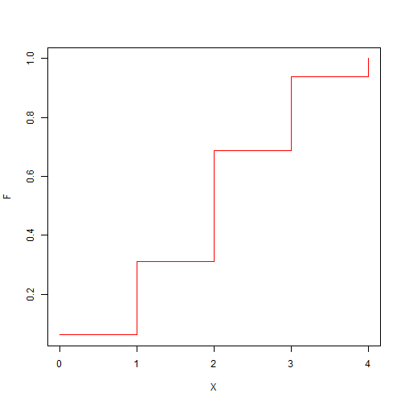

# Distribución de probabilidad

$F(x)$ satisface:

- $0\leq F(x) \leq 1$
- Si $x \leq y$, entonces $F (x) \leq F (y)$

# Distribución de probabilidad

Calcula la función de masa de probabilidad de la siguiente Distribución de probabilidad :

$F(0)=1/16$, $F(1)=5/16$, $F(2)=11/16$, $F(3)=15/16$, $F(4)=16/16$,

Trabajemos al revés de la distribución a la función de probabilidad.

# Distribución de probabilidad

La Distribución de probabilidad es otra forma de especificar la probabilidad de una variable aleatoria

$$f(x_i)=F(x_i)-F(x_{i-1})$$

con

$$f(x_1)=F(x_1)$$

para $X$ tomando valores en $x_1 \leq x_2 \leq ... \leq x_n$

# Resumen

| cantidad | modelo | datos |
| --- | --- | --- |
| función de masa de probabilidad / frecuencia relativa | $P(X=x_i)=f(x_i)$ | $f_i=\frac{n_i}{n}$ |
| función de probabilidad acumulada / frecuencia relativa acumulada | $F(x_i)=P(X \leq x_i)$ | $F_i=\sum_{j\leq j} f_i$ |
| media / media (1er momento sobre el origen) | $\mu$, $\mu'_1$, $E(X)=\sum_{i(resultado)} x_i f(x_i)$ | $\bar{x}=\sum_{j(observación)} x_j/n$ |
| varianza (segundo momento sobre la media) | $\sigma^2$, $\mu_2$, $V(X)=\sum_i (x_i-\mu)^2 f(x_i)$ | $s^2=\sum_j (x_j-\bar{x})^2/(n-1)$ |
| desviación estándar | $\sigma$, $\sqrt{V(X)}$ | $s$ |
| 2º momento sobre el origen | $\mu'_2$,$E(X^2)=\sum_i (x_i)^2 f(x_i)$ | $M'_2=\sum_j x_j^2/n$ |

# Resumen

- $V(x)=E(X^2)-\mu^2$
- $E(X^r)=\mu'_r$ r-momento sobre el **origen**
- $E((X-\mu)^r)=\mu_r$ r-momento sobre la **media**